# Random Forest

Etibar Aliyev

4/26/2020

**Packages**

```r
library("dplyr")
library("naniar")
library(magrittr)
library("car")
library("caret")
library("tidyverse")
library(broom)
theme_set(theme_classic())
library(pROC)
library("ROCR")
library(mlbench)
library(caret)
library(randomForest)
require(caTools)
```

**Read data**

```r
diabetic <- read.csv(file="diabetic.csv", header=T, na.strings = "?")
diabetic2 <- subset(diabetic, select=-c(weight,payer_code))
```

#Early readmission variable

```r
diabetic2 %<>%
mutate(early.readmit=case_when(
 readmitted  %in% "<30" ~ 1,
 readmitted %in% c(">30","NO") ~ 0 ))
```

#Create new HbA1c variable

```r
diabetic2$HbA1c <- ifelse(diabetic$A1Cresult == "None","None",
ifelse(diabetic$A1Cresult == '>8' & diabetic2$change == 'Ch','High-change',      ifelse(diabetic$A1Cresult == '>8' & diabetic2$change == 'No','High-no change',   ifelse(diabetic$A1Cresult == '>7' | diabetic2$A1Cresult == 'Norm','Normal',0))))
```

#Gender

```r
diabetic2 %<>% replace_with_na(replace = list(gender = "Unknown/Invalid"))
```

#Discharge disposition

```r
diabetic2 %<>%
mutate(discharge_disposition=case_when(
 discharge_disposition_id %in% 1 ~ "Discharged to home",
 discharge_disposition_id %in% 2:29 ~ "Otherwise" ))
```

#Admission source

```r
diabetic2 %<>%
mutate(admission.source=case_when(
 admission_source_id %in% c(7) ~ "Emergency",
 admission_source_id %in% c(1,2) ~ "Physician/Clinic",
 admission_source_id %in% c(3:6,8:26) ~ "Otherwise"
))
```

#Admitting physician specialty

```r
diabetic2$admit.spec <-
ifelse(is.na(diabetic2$medical_specialty), "Unknown",
ifelse(diabetic2$medical_specialty == "InternalMedicine","IntMed",
ifelse(diabetic$medical_specialty == 'Cardiology','Card',      ifelse(startsWith(as.character(diabetic2$medical_specialty), "Surg"),'Surg',   ifelse(diabetic2$medical_specialty == 'Family/GeneralPractice','F-GP', 'Other')))))
```

#Primary diagnosis

```r
diabetic2$prim.diag <- ifelse(diabetic2$diag_1>=390 &                                                             diabetic2$diag_1<=459 |
                              diabetic2$diag_1==785,
                              "Circulatory",
                       ifelse(diabetic2$diag_1>=460 &
                              diabetic2$diag_1<=519 |
                              diabetic2$diag_1==786,
                              "Respiratory",
                       ifelse(diabetic2$diag_1>=520 &
                              diabetic2$diag_1<=579 |
                              diabetic2$diag_1==787,
                              "Digestive",
                       ifelse(diabetic2$diag_1>=250.0 &
                              diabetic2$diag_1<251.0,
                              "Diabetes",
                       ifelse(diabetic2$diag_1>=800 &
                              diabetic2$diag_1<=999,
                              "Injury",
                       ifelse(diabetic2$diag_1>=710 &
                              diabetic2$diag_1<=739,
                              "Musculoskeletal",
                       ifelse(diabetic2$diag_1>=580 &
                              diabetic2$diag_1<=629 |
                              diabetic2$diag_1==788,
                              "Genitourinary",
                       ifelse(diabetic2$diag_1>=140 &
                              diabetic2$diag_1<=239,
                              "Neoplasms", "Other"))))))))
View(diabetic2$prim.diag)
```

#Race

```r
diabetic2 %<>%
mutate(race2=case_when(
 race %in% c("AfricanAmerican")~"AfricanAmerican" ,
 race %in% c("Caucasian")~"Caucasian" ,
 race %in% c("Asian","Hispanic","Other")~"Other" ,
 is.na(race)~"Missing"
))
```

#Age

```r
diabetic2 %<>%
mutate(age3=case_when(
 age %in% c("[0-10)","[10-20)","[20-30)")~"30 years old or younger" ,
 age %in% c("[30-40)","[40-50)","[50-60)")~"30 years old to 60 years old" ,
 age %in% c("[60-70)","[70-80)","[80-90)","[90-100)")~"60 years old or older"
))
```

#Create numeric Age variable

```r
diabetic2 %<>%
mutate(age.num=case_when(
 age %in% c("[0-10)")~5 ,
 age %in% c("[10-20)")~15 ,
 age %in% c("[20-30)")~25 ,
 age %in% c("[30-40)")~35 ,
 age %in% c("[40-50)")~45 ,
 age %in% c("[50-60)")~55 ,
 age %in% c("[60-70)")~65 ,
 age %in% c("[70-80)")~75 ,
 age %in% c("[80-90)")~85 ,
 age %in% c("[90-100)")~95
))
```

#Drop observations Select first patient visit if multiple visits: Results in 71518 observations.

```r
diabetic.unique <- distinct(diabetic2, patient_nbr, .keep_all= TRUE)
```

#Remove patients discharged to hospice: Results in 70198 observations

```r
diabetic.unique2 <- subset(diabetic.unique, discharge_disposition_id != 13)
diabetic.unique3 <- subset(diabetic.unique2, discharge_disposition_id!=14)
```

#Remove patients who died: Results in 69973 observations.

```r
diabetic.unique4 <- subset(diabetic.unique3, discharge_disposition_id!=11)

diabetic.unique5 <- subset(diabetic.unique4, discharge_disposition_id!=19)

diabetic.unique6 <- subset(diabetic.unique5, discharge_disposition_id!=20)

diabetic.unique7 <- subset(diabetic.unique6, discharge_disposition_id!=21)
```

#Before running random forest transforming variables into factor and numeric variable as per na.action = na.roughfix requirement

```r
diabetic.unique7 <- transform(
  diabetic.unique7,
  early.readmit = as.factor(early.readmit),
  discharge_disposition_id = as.factor(discharge_disposition_id),
  admission_source_id =as.factor(admission_source_id),
  medical_specialty = as.factor(medical_specialty),
  age = as.factor(age),
  HbA1c=as.factor(HbA1c),
  diag_1 = as.numeric(diag_1),
  race = as.factor(race),
  admit.spec = as.factor(admit.spec),
  prim.diag = as.factor(prim.diag)
  )
sapply(diabetic.unique7, class)
```

```
##             encounter_id              patient_nbr                     race
##                "integer"                "integer"                 "factor"
##                   gender                      age        admission_type_id
##              "character"                 "factor"                "integer"
## discharge_disposition_id      admission_source_id         time_in_hospital
##                 "factor"                 "factor"                "integer"
##        medical_specialty       num_lab_procedures           num_procedures
##                 "factor"                "integer"                "integer"
##          num_medications        number_outpatient         number_emergency
##                "integer"                "integer"                "integer"
##         number_inpatient                   diag_1                   diag_2
##                "integer"                "numeric"              "character"
##                   diag_3         number_diagnoses            max_glu_serum
##              "character"                "integer"              "character"
##                A1Cresult                metformin              repaglinide
##              "character"              "character"              "character"
##              nateglinide           chlorpropamide              glimepiride
##              "character"              "character"              "character"
##            acetohexamide                glipizide                glyburide
##              "character"              "character"              "character"
##              tolbutamide             pioglitazone            rosiglitazone
##              "character"              "character"              "character"
##                 acarbose                 miglitol             troglitazone
##              "character"              "character"              "character"
##               tolazamide                  examide              citoglipton
##              "character"              "character"              "character"
##                  insulin      glyburide.metformin      glipizide.metformin
##              "character"              "character"              "character"
## glimepiride.pioglitazone  metformin.rosiglitazone   metformin.pioglitazone
##              "character"              "character"              "character"
##                   change              diabetesMed               readmitted
##              "character"              "character"              "character"
##            early.readmit                    HbA1c    discharge_disposition
##                 "factor"                 "factor"              "character"
##         admission.source               admit.spec                prim.diag
##              "character"                 "factor"                 "factor"
##                    race2                     age3                  age.num
##              "character"              "character"                "numeric"
```

#Creating train, test subsets

```r
sample = sample.split(diabetic.unique7$early.readmit, SplitRatio = .75)
train = subset(diabetic.unique7, sample == TRUE)
test  = subset(diabetic.unique7, sample == FALSE)
```

```r
dim(train)
```

```
## [1] 52480    57
```

```r
dim(test)
```

```
## [1] 17493    57
```

#Running random forest and prediction

```r
rf <- randomForest(
  early.readmit ~ discharge_disposition_id +  admit.spec+ race + prim.diag+
          admission_source_id + time_in_hospital + age.num + HbA1c,data=train,na.action= na.roughfix
)

pred = predict(rf, newdata=test[-49])
cm = table(test[,49], pred)
print(cm)
```

```
##    pred
##         0     1
##   0 15458    16
##   1  1518    12
```

```r
confusionMatrix(pred, test$early.readmit)
```

```
## Confusion Matrix and Statistics
##
##           Reference
## Prediction     0     1
##          0 15458  1518
##          1    16    12
##
##                Accuracy : 0.9098
##                  95% CI : (0.9054, 0.9141)
##     No Information Rate : 0.91
##     P-Value [Acc > NIR] : 0.5494
##
##                   Kappa : 0.0122
##
##  Mcnemar's Test P-Value : <2e-16
##
##             Sensitivity : 0.998966
##             Specificity : 0.007843
##          Pos Pred Value : 0.910580
##          Neg Pred Value : 0.428571
##              Prevalence : 0.910021
##          Detection Rate : 0.909080
##    Detection Prevalence : 0.998353
##       Balanced Accuracy : 0.503405
##
##        'Positive' Class : 0
##
```

#Checking class error

```r
rf$confusion[, 'class.error']
```

```
##           0           1
## 0.001109436 0.992141037
```

#Variable importance

```r
# estimate variable importance
importance <- varImp(rf, scale=FALSE)
# summarize importance
print(importance)
```

```
##                           Overall
## discharge_disposition_id 494.7867
## admit.spec               337.2241
## race                     228.0511
## prim.diag                469.5531
## admission_source_id      359.1989
## time_in_hospital         554.7909
## age.num                  396.2492
## HbA1c                    213.6034
```

#Plotting variable importance

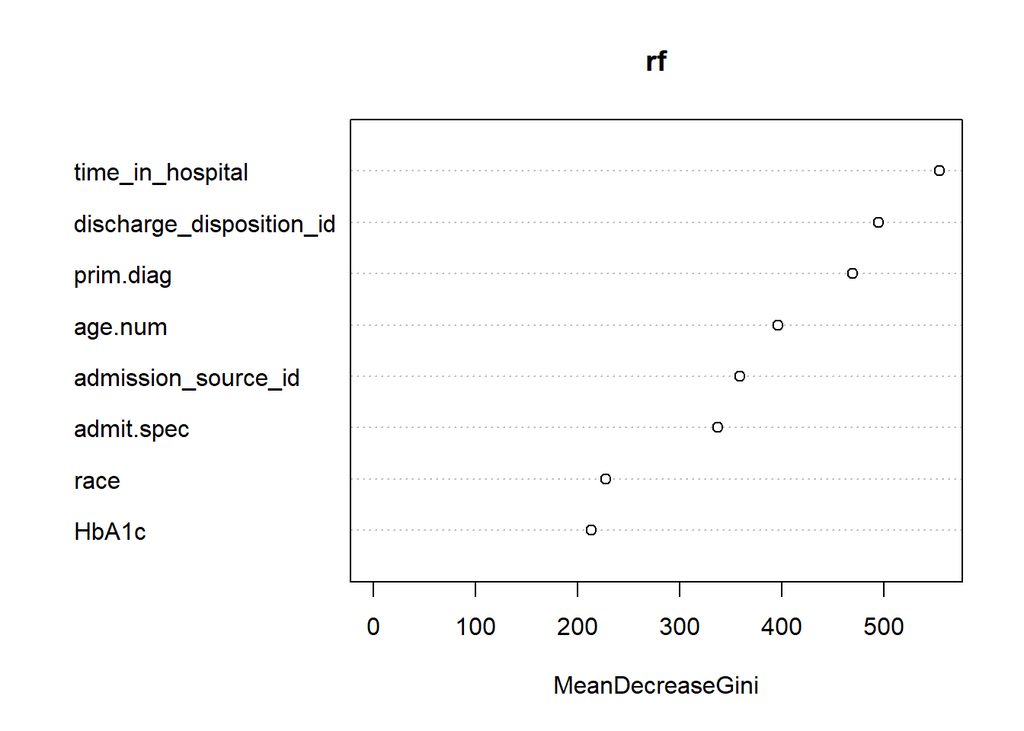

```r
varImpPlot(rf,type=2)
```

#Above given results and plot show that the most 3 important variables are time_in_hospital, discharge_disposition_id and prim diag.